# Overview of General and Specific R NLP Libraries

R has many NLP libraries. These are enumerated in the [CRAN Task View](https://cran.r-project.org/web/views/NaturalLanguageProcessing.html). This document will provide a summary and example code from the most basic pre-processing libraries, and libraries that provide specific functionality not found in elsewhere.

# General frameworks

- TextMining, tm
- [package](https://r-forge.r-project.org/projects/tm/)
- [doc: Text Mining Infrastructure in R](http://www.jstatsoft.org/v25/i05/)
- tidytext
- [packge](https://github.com/juliasilge/tidytext)
- [doc: Text Mining with R a tidy approach](https://www.tidytextmining.com/index.html)

### TextMining

tm provides a framework for flexible integration of premier statistical methods from R, interfaces to well known open source text mining infrastructure and methods, and has a sophisticated modularized extension mechanism for text mining purposes.

### General Workflow

You can head over to [Kaggle](https://www.kaggle.com/kaggle/hillary-clinton-emails/downloads/hillary-clinton-emails.zip) to download the Hillary email dataset.

```r
pkgs<- c("tm", "stopwords", "textclean", "stringr", "lexicon",
         "plyr", "RTextTools", "maxent", "e1071", "caret", "tau")

lapply(pkgs, require, character.only =TRUE)
```

```r
library(RSQLite)
file_path <- paste(getwd(),"/Data/hillary-clinton-emails/database.sqlite",sep='')
db <- dbConnect(dbDriver("SQLite"), file_path)
```

```r
emailHillary <- dbGetQuery(db, "SELECT ExtractedBodyText EmailBody FROM Emails e INNER JOIN Persons p ON e.SenderPersonId=P.Id WHERE p.Name='Hillary Clinton'  AND e.ExtractedBodyText != '' ORDER BY RANDOM()")
dbDisconnect(db)
```

```r
emailRaw <- paste(emailHillary$EmailBody, collapse=" // ")
typeof(emailRaw)
```

```r
# Transform and clean the text
library("tm")
docs <- Corpus(VectorSource(emailRaw))
# Convert the text to lower case
docs <- tm_map(docs, content_transformer(tolower))
# Remove numbers
docs <- tm_map(docs, removeNumbers)
# Remove english common stopwords
docs <- tm_map(docs, removeWords, stopwords("english"))
# Remove punctuations
docs <- tm_map(docs, removePunctuation)
# Eliminate extra white spaces
docs <- tm_map(docs, stripWhitespace)
```

```r
# Text stemming (reduces words to their root form)
library("SnowballC")
docs <- tm_map(docs, stemDocument)
# Remove additional stopwords
docs <- tm_map(docs, removeWords, c("clintonemailcom", "stategov", "hrod"))
dtm <- TermDocumentMatrix(docs)
m <- as.matrix(dtm)
v <- sort(rowSums(m),decreasing=TRUE)
d <- data.frame(word = names(v),freq=v)
head(d, 10)
```

|  | word | freq |
| --- | --- | --- |
| can | can | 403 |
| call | call | 301 |
| pls | pls | 235 |
| will | will | 228 |
| hrodclintonemailcom | hrodclintonemailcom | 202 |
| thx | thx | 196 |
| see | see | 165 |
| print | print | 158 |
| get | get | 153 |
| know | know | 148 |

```r
# Generate the WordCloud
library("wordcloud")
library("RColorBrewer")

par(bg="grey30")
png(file="WordCloud.png",width=1000,height=700, bg="grey30")
wordcloud(d$word, d$freq, col=terrain.colors(length(d$word), alpha=0.9), random.order=FALSE, rot.per=0.3 )
title(main = "Hillary Clinton's Most Used Words in the Emails", font.main = 1, col.main = "cornsilk3", cex.main = 1.5)
dev.off()
```

[figure not shown]

```r
library("png")
pp <- readPNG("images/WordCloud.png")
plot.new()
rasterImage(pp,0,0,1,1)
```

```r
library(RSQLite)
file_path <- paste(getwd(),"/Data/hillary-clinton-emails/database.sqlite",sep='')
db <- dbConnect(dbDriver("SQLite"), file_path)
Emails <- data.frame(dbGetQuery(db,"SELECT * FROM Emails"))
```

```r
# Sentiment Analysis
Emails <- data.frame(dbGetQuery(db,"SELECT * FROM Emails"))
```

```
Column `SenderPersonId`: mixed type, first seen values of type integer, coercing other values of type string
```

```r
library('syuzhet')
d<-get_nrc_sentiment(Emails$RawText)
td<-data.frame(t(d))

td_new <- data.frame(rowSums(td[2:7945]))
#The function rowSums computes column sums across rows for each level of a grouping variable.

#Transformation and cleaning
names(td_new)[1] <- "count"
td_new <- cbind("sentiment" = rownames(td_new), td_new)
rownames(td_new) <- NULL
td_new2<-td_new[1:8,]
```

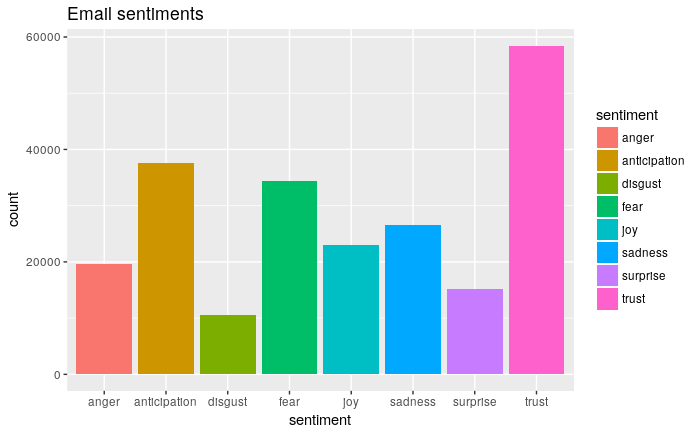

```r
#Visualisation
library("ggplot2")
qplot(sentiment, data=td_new2, weight=count, geom="bar",fill=sentiment)+ggtitle("Email sentiments")
```

```r
# N-grams
library(tm)
library(RSQLite)
library(quanteda)

# Get all the emails sent by Hillary
emailHillary <- dbGetQuery(db, "SELECT ExtractedBodyText EmailBody FROM Emails e INNER JOIN Persons p ON e.SenderPersonId=P.Id WHERE p.Name='Hillary Clinton' AND e.ExtractedBodyText != '' ORDER BY RANDOM()")
emails <- paste(emailHillary$EmailBody, collapse=" // ")
#Remove stopwords
textstat_collocations(emails, size = 2:3)
```

|  | collocation | count | count_nested | length | lambda | z |
| --- | --- | --- | --- | --- | --- | --- |
| 1 | pls print | 90 | 33 | 2 | 5.652866 | 31.030326 |
| 2 | can you | 136 | 136 | 2 | 3.461270 | 30.097314 |
| 3 | h < | 219 | 219 | 2 | 9.940078 | 28.936906 |
| 4 | pis print | 53 | 10 | 2 | 5.372723 | 26.272170 |
| 5 | i'd like | 49 | 49 | 2 | 7.473092 | 24.565508 |
| 6 | me know | 52 | 52 | 2 | 4.567408 | 24.187992 |
| 7 | know what | 31 | 31 | 2 | 5.161964 | 21.279811 |
| 8 | let's discuss | 24 | 18 | 2 | 5.994232 | 20.342748 |
| 9 | next week | 22 | 22 | 2 | 6.559499 | 19.939093 |
| 10 | PART B6 | 29 | 29 | 2 | 8.136901 | 19.829338 |

[output cut: 990 more lines]

```r
#print(removeFeatures(textstat_collocations(emails, size = 2:3), stopwords("english")))    #deprecated
print(textstat_collocations(emails, size = 2:3))
```

|  | collocation | count | count_nested | length | lambda | z |
| --- | --- | --- | --- | --- | --- | --- |
| 1 | pls print | 90 | 33 | 2 | 5.652866 | 31.030326 |
| 2 | can you | 136 | 136 | 2 | 3.461270 | 30.097314 |
| 3 | h < | 219 | 219 | 2 | 9.940078 | 28.936906 |
| 4 | pis print | 53 | 10 | 2 | 5.372723 | 26.272170 |
| 5 | i'd like | 49 | 49 | 2 | 7.473092 | 24.565508 |
| 6 | me know | 52 | 52 | 2 | 4.567408 | 24.187992 |
| 7 | know what | 31 | 31 | 2 | 5.161964 | 21.279811 |
| 8 | let's discuss | 24 | 18 | 2 | 5.994232 | 20.342748 |
| 9 | next week | 22 | 22 | 2 | 6.559499 | 19.939093 |
| 10 | PART B6 | 29 | 29 | 2 | 8.136901 | 19.829338 |

[output cut: 990 more lines]

# Specific Frameworks

- SnowballC, text stemming library
- Wordcloud, for making wordcloud visualizations
- Syuzhet, text sentiment analysis
- quanteda, N-grams